# Analysis of pinger results

Ben Anderson (@dataknut)

# About this document

Last run: 2016-05-04 07:42:45

This document was created using knitr in [RStudio](http://www.rstudio.com). Knitr allows the embedding of R code within markdown text documents allowing them to be updated and re-run. Things to note:

- Knitr will display warnings (but not errors) from R. The warnings may or may not be significant.
- Knitr is very clever but it does not always support pretty tables.

This code processes and anlayses the results of running https://github.com/dataknut/ping-log/blob/master/pinger.py. The results will be a .csv file with the form:

```
timestamp,host,milliseconds, error
2016-04-28 10:53:56,www.google.co.uk,83.548, OK
2016-04-28 10:53:57,router,121.820, OK
2016-04-28 10:54:07,www.google.co.uk,71.019, OK
2016-04-28 10:54:07,router,9.875, OK
```

# Introduction

Purpose:

- To test connectivity to:
  - a home router and
  - the wider internet
- in order to attempt to work out where connectivity problems are occuring.

Data:

- Any number of .csv files produced by pinger.py

Code:

- this code: https://github.com/dataknut/ping-log/blob/master/pinger_process_results.Rmd

Warning:

- the code lines up the data files according to the datetime in them. If this is wrong (e.g. wrong timezone set or using UTC) then there will be mis-alignment.

# Load any pinger results files

You may see file read warnings below. They are usually caused by:

- incorrect handling of ping response errors putting characters into the milliseconds field
- unexpected file ending - e.g. when the pinger process quit without closing the file

All of these are re-coded as different types of ‘error’ before any data analysis.

```
## [1] "# Loading: hamishpi_2016-04-29_13-54-42.csv"
```

```
## [1] "# Loading: hamishpi_on_ethernet_2016-04-28_12-20-56.csv"
```

```
## [1] "# Loading: ms_mbp_2016-04-29_23-12-00.csv"
## [1] "# Loading: ms_mbp_kitchen_wifi_2016-04-28_19-17-44.csv"
## [1] "# Loading: msmbp_on_kitchen_wifi_2016-04-29_11-09-24.csv"
## [1] "# Loading: octomac_2016-04-29_14-50-08.csv"
## [1] "# Loading: octomac_2016-04-29_14-59-53.csv"
## [1] "# Loading: octomac_2016-05-04_00-30-23.csv"
## [1] "# Loading: octomac_on_annex_wifi_2016-04-28_13-22-59.csv"
## [1] "# Loading: pimine_2016-04-29_13-58-14.csv"
```

```
## [1] "# Loading: pimine_on_bthub_2016-04-28_12-22-29.csv"
```

```
## [1] "# Loading: pimine_on_bthub_2016-04-29_15-24-09.csv"
```

```
## [1] "# Loading: pimine_on_bthub_balcony_2016-04-28_12-22-29.csv"
```

```
## [1] "# Loading: pimine_on_bthub_kitchen_2016-04-29_09-59-29.csv"
```

# Basic responses

Throughout the following NA usually means ping failed to return.

Files we processed:

```
##  [1] "pinger_hamishpi_2016-04-29_13-54-42_DT.csv"
##  [2] "pinger_hamishpi_on_ethernet_2016-04-28_12-20-56_DT.csv"
##  [3] "pinger_ms_mbp_2016-04-29_23-12-00_DT.csv"
##  [4] "pinger_ms_mbp_kitchen_wifi_2016-04-28_19-17-44_DT.csv"
##  [5] "pinger_msmbp_on_kitchen_wifi_2016-04-29_11-09-24_DT.csv"
##  [6] "pinger_octomac_2016-04-29_14-50-08_DT.csv"
##  [7] "pinger_octomac_2016-04-29_14-59-53_DT.csv"
##  [8] "pinger_octomac_2016-05-04_00-30-23_DT.csv"
##  [9] "pinger_octomac_on_annex_wifi_2016-04-28_13-22-59_DT.csv"
## [10] "pinger_pimine_2016-04-29_13-58-14_DT.csv"
## [11] "pinger_pimine_on_bthub_2016-04-28_12-22-29_DT.csv"
## [12] "pinger_pimine_on_bthub_2016-04-29_15-24-09_DT.csv"
## [13] "pinger_pimine_on_bthub_balcony_2016-04-28_12-22-29_DT.csv"
## [14] "pinger_pimine_on_bthub_kitchen_2016-04-29_09-59-29_DT.csv"
```

How many rows (cases) & variables across all files?

```
## [1] 203956     10
```

|  | router | www.google.co.uk | NA |
| --- | --- | --- | --- |
| hamishpi | 11017 | 11017 | 0 |
| ms_mbp | 33612 | 33612 | 0 |
| octomac | 12010 | 12010 | 0 |
| pimine_bthub | 45339 | 45339 | 0 |
| NA | 0 | 0 | 0 |

Distribution of milliseconds?

| label | Mean | N | s.d |
| --- | --- | --- | --- |
| hamishpi | 251.12219 | 18381 | 851.3859 |
| ms_mbp | 253.11869 | 66178 | 818.5563 |
| octomac | 416.35708 | 20325 | 1161.4414 |
| pimine_bthub | 41.37784 | 89486 | 321.0563 |

# Ping error results

Did we get any errors?

|  | hamishpi | ms_mbp | octomac | pimine_bthub | NA |
| --- | --- | --- | --- | --- | --- |
| connect: Network is unreachable | 0 | 0 | 0 | 364 | 0 |
| OK | 18381 | 66170 | 20122 | 89486 | 0 |
| ping error: ‘36’ | 0 | 0 | 26 | 0 | 0 |
| ping error: ‘92’ | 0 | 8 | 177 | 0 | 0 |
| ping error: `From’ | 624 | 0 | 0 | 34 | 0 |
| ping error: no value returned | 1269 | 0 | 0 | 39 | 0 |
| ping: unknown host www.google.co.uk | 1760 | 0 | 0 | 742 | 0 |
| NA | 0 | 1046 | 3695 | 13 | 0 |

What time of day do we tend to get errors?

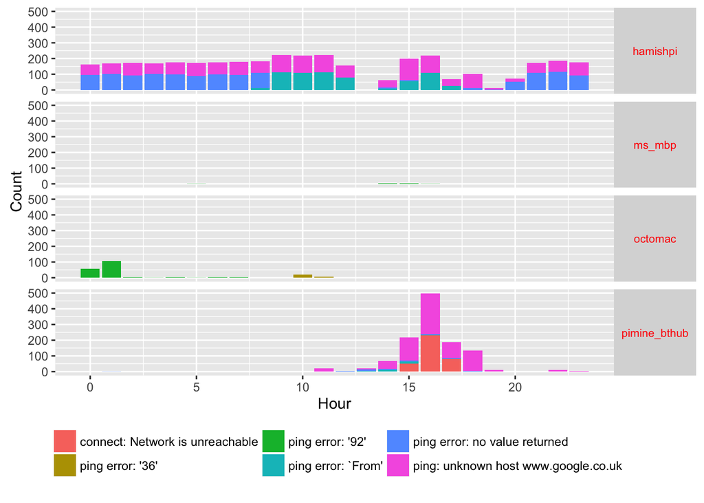

# Ping response time results

Ping data, key stats for 2016-04-28 12:20:57 to 2016-05-04 07:42:33 for all data sources. Beware datetime issues on the Raspberry Pi.

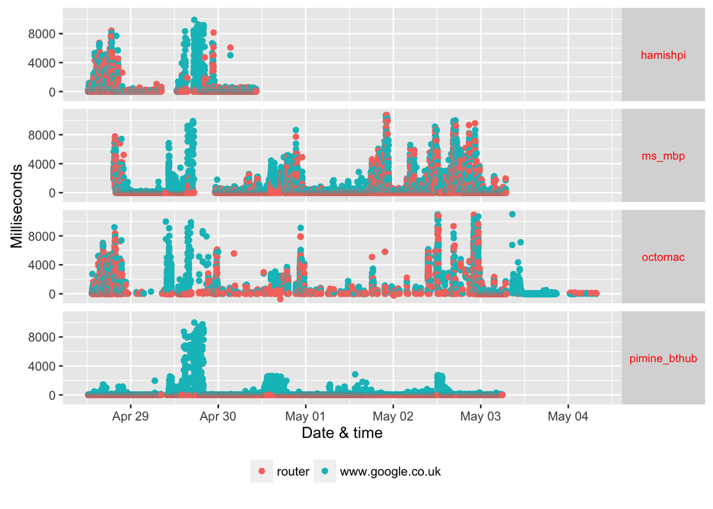

Fairly conclusively:

- there is rarely a problem with our broadband service - pimine on the bthub generally shows low response times
- most of the problems are internal (no s**t Sherlock)

If we now consider the results by hour of the day:

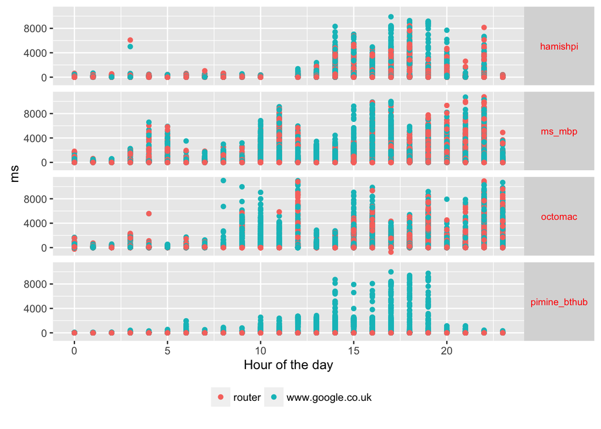

Equally conclusively:

It is the *only* problem period for the bthub (noting that for some reason, pimine_on_bthub’s clock is 1 hour behind BST). Strangely enough this is also the period when the iPads-belonging-to-teenagers have internet access.

Last run: 2016-05-04 07:43:47

Data tables in memory:

Analysis completed in: 1.0393457 seconds using knitr & [RStudio](http://www.rstudio.com)